# Risk Factor Analysis

## Outcome Variable

**Outcome Variable:** y_rate_haz

## Predictor Variables

**Intervention Variable:** cleanck

**Adjustment Set:**

- arm
- sex
- W_mage
- meducyrs
- feducyrs
- hhwealth_quart
- W_mhtcm
- W_mwtkg
- W_mbmi
- W_nrooms
- W_nhh
- W_nchldlt5
- trth2o
- impfloor
- impsan
- safeh20
- delta_meducyrs
- delta_feducyrs
- delta_hhwealth_quart
- delta_W_mhtcm
- delta_W_mwtkg
- delta_W_mbmi
- delta_W_nrooms
- delta_W_nhh
- delta_W_nchldlt5
- delta_trth2o
- delta_impfloor
- delta_impsan
- delta_safeh20

## Stratifying Variables

The analysis was stratified on these variable(s):

- agecat
- studyid
- country

## Data Summary

| agecat | studyid | country | cleanck | n_cell | n |
| --- | --- | --- | --- | --- | --- |
| 0-3 months | ki1017093b-PROVIDE | BANGLADESH | 0 | 109 | 634 |
| 0-3 months | ki1017093b-PROVIDE | BANGLADESH | 1 | 525 | 634 |
| 0-3 months | ki1017093c-NIH-Crypto | BANGLADESH | 0 | 213 | 546 |
| 0-3 months | ki1017093c-NIH-Crypto | BANGLADESH | 1 | 333 | 546 |
| 0-3 months | ki1000108-CMC-V-BCS-2002 | INDIA | 0 | 48 | 87 |
| 0-3 months | ki1000108-CMC-V-BCS-2002 | INDIA | 1 | 39 | 87 |
| 0-3 months | ki1000108-IRC | INDIA | 0 | 157 | 369 |
| 0-3 months | ki1000108-IRC | INDIA | 1 | 212 | 369 |
| 0-3 months | ki0047075b-MAL-ED | PERU | 1 | 1 | 1 |
| 0-3 months | ki0047075b-MAL-ED | SOUTH AFRICA | 0 | 1 | 2 |
| 0-3 months | ki0047075b-MAL-ED | SOUTH AFRICA | 1 | 1 | 2 |
| 3-6 months | ki1017093b-PROVIDE | BANGLADESH | 0 | 99 | 574 |
| 3-6 months | ki1017093b-PROVIDE | BANGLADESH | 1 | 475 | 574 |
| 3-6 months | ki1017093c-NIH-Crypto | BANGLADESH | 0 | 212 | 527 |
| 3-6 months | ki1017093c-NIH-Crypto | BANGLADESH | 1 | 315 | 527 |
| 3-6 months | ki1000108-CMC-V-BCS-2002 | INDIA | 0 | 174 | 307 |
| 3-6 months | ki1000108-CMC-V-BCS-2002 | INDIA | 1 | 133 | 307 |
| 3-6 months | ki1000108-IRC | INDIA | 0 | 166 | 390 |
| 3-6 months | ki1000108-IRC | INDIA | 1 | 224 | 390 |
| 3-6 months | ki1113344-GMS-Nepal | NEPAL | 0 | 420 | 426 |
| 3-6 months | ki1113344-GMS-Nepal | NEPAL | 1 | 6 | 426 |
| 3-6 months | ki0047075b-MAL-ED | SOUTH AFRICA | 1 | 1 | 1 |
| 6-12 months | ki1017093b-PROVIDE | BANGLADESH | 0 | 96 | 545 |
| 6-12 months | ki1017093b-PROVIDE | BANGLADESH | 1 | 449 | 545 |
| 6-12 months | ki1017093c-NIH-Crypto | BANGLADESH | 0 | 214 | 516 |
| 6-12 months | ki1017093c-NIH-Crypto | BANGLADESH | 1 | 302 | 516 |
| 6-12 months | ki1000108-CMC-V-BCS-2002 | INDIA | 0 | 185 | 323 |
| 6-12 months | ki1000108-CMC-V-BCS-2002 | INDIA | 1 | 138 | 323 |
| 6-12 months | ki1000108-IRC | INDIA | 0 | 164 | 391 |
| 6-12 months | ki1000108-IRC | INDIA | 1 | 227 | 391 |
| 6-12 months | ki1113344-GMS-Nepal | NEPAL | 0 | 420 | 428 |
| 6-12 months | ki1113344-GMS-Nepal | NEPAL | 1 | 8 | 428 |
| 6-12 months | ki0047075b-MAL-ED | SOUTH AFRICA | 1 | 1 | 1 |
| 12-24 months | ki1017093b-PROVIDE | BANGLADESH | 0 | 80 | 458 |
| 12-24 months | ki1017093b-PROVIDE | BANGLADESH | 1 | 378 | 458 |
| 12-24 months | ki1017093c-NIH-Crypto | BANGLADESH | 0 | 211 | 396 |
| 12-24 months | ki1017093c-NIH-Crypto | BANGLADESH | 1 | 185 | 396 |
| 12-24 months | ki1000108-CMC-V-BCS-2002 | INDIA | 0 | 191 | 324 |
| 12-24 months | ki1000108-CMC-V-BCS-2002 | INDIA | 1 | 133 | 324 |
| 12-24 months | ki1000108-IRC | INDIA | 0 | 163 | 387 |
| 12-24 months | ki1000108-IRC | INDIA | 1 | 224 | 387 |
| 12-24 months | ki1113344-GMS-Nepal | NEPAL | 0 | 323 | 328 |
| 12-24 months | ki1113344-GMS-Nepal | NEPAL | 1 | 5 | 328 |
| 12-24 months | ki0047075b-MAL-ED | SOUTH AFRICA | 1 | 1 | 1 |

The following strata were considered:

- agecat: 0-3 months, studyid: ki0047075b-MAL-ED, country: PERU
- agecat: 0-3 months, studyid: ki0047075b-MAL-ED, country: SOUTH AFRICA
- agecat: 0-3 months, studyid: ki1000108-CMC-V-BCS-2002, country: INDIA
- agecat: 0-3 months, studyid: ki1000108-IRC, country: INDIA
- agecat: 0-3 months, studyid: ki1017093b-PROVIDE, country: BANGLADESH
- agecat: 0-3 months, studyid: ki1017093c-NIH-Crypto, country: BANGLADESH
- agecat: 12-24 months, studyid: ki0047075b-MAL-ED, country: SOUTH AFRICA
- agecat: 12-24 months, studyid: ki1000108-CMC-V-BCS-2002, country: INDIA
- agecat: 12-24 months, studyid: ki1000108-IRC, country: INDIA
- agecat: 12-24 months, studyid: ki1017093b-PROVIDE, country: BANGLADESH
- agecat: 12-24 months, studyid: ki1017093c-NIH-Crypto, country: BANGLADESH
- agecat: 12-24 months, studyid: ki1113344-GMS-Nepal, country: NEPAL
- agecat: 3-6 months, studyid: ki0047075b-MAL-ED, country: SOUTH AFRICA
- agecat: 3-6 months, studyid: ki1000108-CMC-V-BCS-2002, country: INDIA
- agecat: 3-6 months, studyid: ki1000108-IRC, country: INDIA
- agecat: 3-6 months, studyid: ki1017093b-PROVIDE, country: BANGLADESH
- agecat: 3-6 months, studyid: ki1017093c-NIH-Crypto, country: BANGLADESH
- agecat: 3-6 months, studyid: ki1113344-GMS-Nepal, country: NEPAL
- agecat: 6-12 months, studyid: ki0047075b-MAL-ED, country: SOUTH AFRICA
- agecat: 6-12 months, studyid: ki1000108-CMC-V-BCS-2002, country: INDIA
- agecat: 6-12 months, studyid: ki1000108-IRC, country: INDIA
- agecat: 6-12 months, studyid: ki1017093b-PROVIDE, country: BANGLADESH
- agecat: 6-12 months, studyid: ki1017093c-NIH-Crypto, country: BANGLADESH
- agecat: 6-12 months, studyid: ki1113344-GMS-Nepal, country: NEPAL

### Dropped Strata

Some strata were dropped due to rare outcomes:

- agecat: 0-3 months, studyid: ki0047075b-MAL-ED, country: PERU
- agecat: 0-3 months, studyid: ki0047075b-MAL-ED, country: SOUTH AFRICA
- agecat: 3-6 months, studyid: ki0047075b-MAL-ED, country: SOUTH AFRICA
- agecat: 6-12 months, studyid: ki0047075b-MAL-ED, country: SOUTH AFRICA
- agecat: 12-24 months, studyid: ki0047075b-MAL-ED, country: SOUTH AFRICA

## Methods Detail

We’re interested in the causal parameters $E[Y_a]$ for all values of $a \in \mathcal{A}$. These parameters represent the mean outcome if, possibly contrary to fact, we intervened to set all units to have $A=a$. Under the randomization and positivity assumptions, these are identified by the statistical parameters $\psi_a=E_W[E_{Y|A,W}(Y|A=a,W)]$. In addition, we’re interested in the mean of $Y$, $E[Y]$ under no intervention (the observed mean). We will estimate these parameters by using SuperLearner to fit the relevant likelihood factors – $E_{Y|A,W}(Y|A=a,W)$ and $p(A=a|W)$, and then updating our likelihood fit using a joint TMLE.

For unadjusted analyses ($W=\{\}$), initial likelihoods were estimated using Lrnr_glm to estimate the simple $E(Y|A)$ and Lrnr_mean to estimate $p(A)$. For adjusted analyses, a small library containing Lrnr_glmnet, Lrnr_xgboost, and Lrnr_mean was used.

# Results Detail

## Results Plots

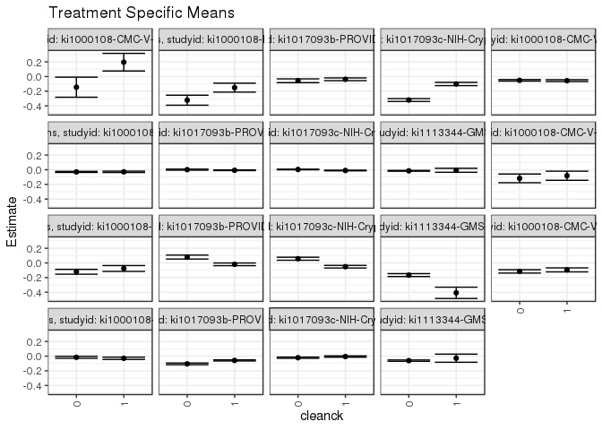

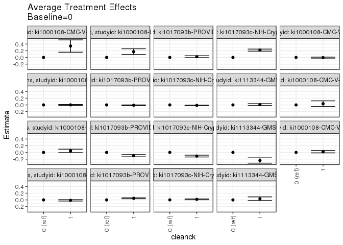

## Results Table

### Parameter: TSM

| agecat | studyid | country | intervention_level | baseline_level | estimate | ci_lower | ci_upper |
| --- | --- | --- | --- | --- | --- | --- | --- |
| 0-3 months | ki1000108-CMC-V-BCS-2002 | INDIA | 0 | NA | -0.1454349 | -0.2822899 | -0.0085798 |
| 0-3 months | ki1000108-CMC-V-BCS-2002 | INDIA | 1 | NA | 0.1955317 | 0.0752850 | 0.3157784 |
| 0-3 months | ki1000108-IRC | INDIA | 0 | NA | -0.3228700 | -0.3911354 | -0.2546046 |
| 0-3 months | ki1000108-IRC | INDIA | 1 | NA | -0.1516866 | -0.2124712 | -0.0909020 |
| 0-3 months | ki1017093b-PROVIDE | BANGLADESH | 0 | NA | -0.0575865 | -0.0835044 | -0.0316685 |
| 0-3 months | ki1017093b-PROVIDE | BANGLADESH | 1 | NA | -0.0376114 | -0.0563922 | -0.0188306 |
| 0-3 months | ki1017093c-NIH-Crypto | BANGLADESH | 0 | NA | -0.3205120 | -0.3397833 | -0.3012408 |
| 0-3 months | ki1017093c-NIH-Crypto | BANGLADESH | 1 | NA | -0.1016197 | -0.1237345 | -0.0795050 |
| 3-6 months | ki1000108-CMC-V-BCS-2002 | INDIA | 0 | NA | -0.1179852 | -0.1772793 | -0.0586911 |
| 3-6 months | ki1000108-CMC-V-BCS-2002 | INDIA | 1 | NA | -0.0819478 | -0.1440884 | -0.0198072 |
| 3-6 months | ki1000108-IRC | INDIA | 0 | NA | -0.1207070 | -0.1540422 | -0.0873718 |
| 3-6 months | ki1000108-IRC | INDIA | 1 | NA | -0.0757231 | -0.1154697 | -0.0359766 |
| 3-6 months | ki1017093b-PROVIDE | BANGLADESH | 0 | NA | 0.0797641 | 0.0529212 | 0.1066069 |
| 3-6 months | ki1017093b-PROVIDE | BANGLADESH | 1 | NA | -0.0191860 | -0.0374511 | -0.0009208 |
| 3-6 months | ki1017093c-NIH-Crypto | BANGLADESH | 0 | NA | 0.0573906 | 0.0368258 | 0.0779555 |
| 3-6 months | ki1017093c-NIH-Crypto | BANGLADESH | 1 | NA | -0.0514256 | -0.0693219 | -0.0335294 |
| 3-6 months | ki1113344-GMS-Nepal | NEPAL | 0 | NA | -0.1660234 | -0.1858022 | -0.1462446 |
| 3-6 months | ki1113344-GMS-Nepal | NEPAL | 1 | NA | -0.4073392 | -0.4843226 | -0.3303558 |
| 6-12 months | ki1000108-CMC-V-BCS-2002 | INDIA | 0 | NA | -0.1154475 | -0.1385728 | -0.0923222 |
| 6-12 months | ki1000108-CMC-V-BCS-2002 | INDIA | 1 | NA | -0.0947070 | -0.1218721 | -0.0675420 |
| 6-12 months | ki1000108-IRC | INDIA | 0 | NA | -0.0157192 | -0.0294111 | -0.0020273 |
| 6-12 months | ki1000108-IRC | INDIA | 1 | NA | -0.0295028 | -0.0449344 | -0.0140712 |
| 6-12 months | ki1017093b-PROVIDE | BANGLADESH | 0 | NA | -0.1054244 | -0.1170421 | -0.0938066 |
| 6-12 months | ki1017093b-PROVIDE | BANGLADESH | 1 | NA | -0.0582530 | -0.0658093 | -0.0506967 |
| 6-12 months | ki1017093c-NIH-Crypto | BANGLADESH | 0 | NA | -0.0213258 | -0.0294802 | -0.0131714 |
| 6-12 months | ki1017093c-NIH-Crypto | BANGLADESH | 1 | NA | -0.0055215 | -0.0148552 | 0.0038122 |
| 6-12 months | ki1113344-GMS-Nepal | NEPAL | 0 | NA | -0.0615046 | -0.0703937 | -0.0526155 |
| 6-12 months | ki1113344-GMS-Nepal | NEPAL | 1 | NA | -0.0282194 | -0.0835507 | 0.0271120 |
| 12-24 months | ki1000108-CMC-V-BCS-2002 | INDIA | 0 | NA | -0.0517875 | -0.0623093 | -0.0412656 |
| 12-24 months | ki1000108-CMC-V-BCS-2002 | INDIA | 1 | NA | -0.0565148 | -0.0693433 | -0.0436862 |
| 12-24 months | ki1000108-IRC | INDIA | 0 | NA | -0.0298457 | -0.0373065 | -0.0223849 |
| 12-24 months | ki1000108-IRC | INDIA | 1 | NA | -0.0286084 | -0.0379726 | -0.0192442 |
| 12-24 months | ki1017093b-PROVIDE | BANGLADESH | 0 | NA | 0.0011610 | -0.0061080 | 0.0084300 |
| 12-24 months | ki1017093b-PROVIDE | BANGLADESH | 1 | NA | -0.0074813 | -0.0117408 | -0.0032217 |
| 12-24 months | ki1017093c-NIH-Crypto | BANGLADESH | 0 | NA | 0.0033616 | -0.0009252 | 0.0076484 |
| 12-24 months | ki1017093c-NIH-Crypto | BANGLADESH | 1 | NA | -0.0103775 | -0.0145901 | -0.0061648 |
| 12-24 months | ki1113344-GMS-Nepal | NEPAL | 0 | NA | -0.0149410 | -0.0203852 | -0.0094968 |
| 12-24 months | ki1113344-GMS-Nepal | NEPAL | 1 | NA | -0.0076372 | -0.0347604 | 0.0194860 |

### Parameter: E(Y)

| agecat | studyid | country | intervention_level | baseline_level | estimate | ci_lower | ci_upper |
| --- | --- | --- | --- | --- | --- | --- | --- |
| 0-3 months | ki1000108-CMC-V-BCS-2002 | INDIA | NA | NA | -0.0732952 | -0.1806423 | 0.0340519 |
| 0-3 months | ki1000108-IRC | INDIA | NA | NA | -0.2555832 | -0.3120360 | -0.1991304 |
| 0-3 months | ki1017093b-PROVIDE | BANGLADESH | NA | NA | -0.0413143 | -0.0594662 | -0.0231624 |
| 0-3 months | ki1017093c-NIH-Crypto | BANGLADESH | NA | NA | -0.1140109 | -0.1341708 | -0.0938510 |
| 3-6 months | ki1000108-CMC-V-BCS-2002 | INDIA | NA | NA | -0.0979615 | -0.1455947 | -0.0503283 |
| 3-6 months | ki1000108-IRC | INDIA | NA | NA | -0.0517747 | -0.0822588 | -0.0212906 |
| 3-6 months | ki1017093b-PROVIDE | BANGLADESH | NA | NA | -0.0272428 | -0.0436954 | -0.0107902 |
| 3-6 months | ki1017093c-NIH-Crypto | BANGLADESH | NA | NA | 0.0302642 | 0.0105575 | 0.0499710 |
| 3-6 months | ki1113344-GMS-Nepal | NEPAL | NA | NA | -0.1695159 | -0.1892757 | -0.1497561 |
| 6-12 months | ki1000108-CMC-V-BCS-2002 | INDIA | NA | NA | -0.0993395 | -0.1199006 | -0.0787784 |
| 6-12 months | ki1000108-IRC | INDIA | NA | NA | -0.0274878 | -0.0401239 | -0.0148518 |
| 6-12 months | ki1017093b-PROVIDE | BANGLADESH | NA | NA | -0.0626151 | -0.0695574 | -0.0556729 |
| 6-12 months | ki1017093c-NIH-Crypto | BANGLADESH | NA | NA | -0.0282840 | -0.0367845 | -0.0197836 |
| 6-12 months | ki1113344-GMS-Nepal | NEPAL | NA | NA | -0.0608825 | -0.0696769 | -0.0520880 |
| 12-24 months | ki1000108-CMC-V-BCS-2002 | INDIA | NA | NA | -0.0455184 | -0.0556929 | -0.0353439 |
| 12-24 months | ki1000108-IRC | INDIA | NA | NA | -0.0313101 | -0.0385075 | -0.0241127 |
| 12-24 months | ki1017093b-PROVIDE | BANGLADESH | NA | NA | -0.0081718 | -0.0120131 | -0.0043304 |
| 12-24 months | ki1017093c-NIH-Crypto | BANGLADESH | NA | NA | -0.0030765 | -0.0074275 | 0.0012744 |
| 12-24 months | ki1113344-GMS-Nepal | NEPAL | NA | NA | -0.0148291 | -0.0202110 | -0.0094472 |

### Parameter: ATE

| agecat | studyid | country | intervention_level | baseline_level | estimate | ci_lower | ci_upper |
| --- | --- | --- | --- | --- | --- | --- | --- |
| 0-3 months | ki1000108-CMC-V-BCS-2002 | INDIA | 0 | 0 | 0.0000000 | 0.0000000 | 0.0000000 |
| 0-3 months | ki1000108-CMC-V-BCS-2002 | INDIA | 1 | 0 | 0.3409666 | 0.1571337 | 0.5247995 |
| 0-3 months | ki1000108-IRC | INDIA | 0 | 0 | 0.0000000 | 0.0000000 | 0.0000000 |
| 0-3 months | ki1000108-IRC | INDIA | 1 | 0 | 0.1711834 | 0.0841966 | 0.2581702 |
| 0-3 months | ki1017093b-PROVIDE | BANGLADESH | 0 | 0 | 0.0000000 | 0.0000000 | 0.0000000 |
| 0-3 months | ki1017093b-PROVIDE | BANGLADESH | 1 | 0 | 0.0199750 | -0.0092528 | 0.0492029 |
| 0-3 months | ki1017093c-NIH-Crypto | BANGLADESH | 0 | 0 | 0.0000000 | 0.0000000 | 0.0000000 |
| 0-3 months | ki1017093c-NIH-Crypto | BANGLADESH | 1 | 0 | 0.2188923 | 0.1884439 | 0.2493406 |
| 3-6 months | ki1000108-CMC-V-BCS-2002 | INDIA | 0 | 0 | 0.0000000 | 0.0000000 | 0.0000000 |
| 3-6 months | ki1000108-CMC-V-BCS-2002 | INDIA | 1 | 0 | 0.0360374 | -0.0498497 | 0.1219244 |
| 3-6 months | ki1000108-IRC | INDIA | 0 | 0 | 0.0000000 | 0.0000000 | 0.0000000 |
| 3-6 months | ki1000108-IRC | INDIA | 1 | 0 | 0.0449839 | -0.0074455 | 0.0974133 |
| 3-6 months | ki1017093b-PROVIDE | BANGLADESH | 0 | 0 | 0.0000000 | 0.0000000 | 0.0000000 |
| 3-6 months | ki1017093b-PROVIDE | BANGLADESH | 1 | 0 | -0.0989500 | -0.1315340 | -0.0663661 |
| 3-6 months | ki1017093c-NIH-Crypto | BANGLADESH | 0 | 0 | 0.0000000 | 0.0000000 | 0.0000000 |
| 3-6 months | ki1017093c-NIH-Crypto | BANGLADESH | 1 | 0 | -0.1088163 | -0.1359672 | -0.0816654 |
| 3-6 months | ki1113344-GMS-Nepal | NEPAL | 0 | 0 | 0.0000000 | 0.0000000 | 0.0000000 |
| 3-6 months | ki1113344-GMS-Nepal | NEPAL | 1 | 0 | -0.2413158 | -0.3207387 | -0.1618929 |
| 6-12 months | ki1000108-CMC-V-BCS-2002 | INDIA | 0 | 0 | 0.0000000 | 0.0000000 | 0.0000000 |
| 6-12 months | ki1000108-CMC-V-BCS-2002 | INDIA | 1 | 0 | 0.0207405 | -0.0142813 | 0.0557623 |
| 6-12 months | ki1000108-IRC | INDIA | 0 | 0 | 0.0000000 | 0.0000000 | 0.0000000 |
| 6-12 months | ki1000108-IRC | INDIA | 1 | 0 | -0.0137836 | -0.0329616 | 0.0053944 |
| 6-12 months | ki1017093b-PROVIDE | BANGLADESH | 0 | 0 | 0.0000000 | 0.0000000 | 0.0000000 |
| 6-12 months | ki1017093b-PROVIDE | BANGLADESH | 1 | 0 | 0.0471714 | 0.0335398 | 0.0608029 |
| 6-12 months | ki1017093c-NIH-Crypto | BANGLADESH | 0 | 0 | 0.0000000 | 0.0000000 | 0.0000000 |
| 6-12 months | ki1017093c-NIH-Crypto | BANGLADESH | 1 | 0 | 0.0158043 | 0.0033236 | 0.0282851 |
| 6-12 months | ki1113344-GMS-Nepal | NEPAL | 0 | 0 | 0.0000000 | 0.0000000 | 0.0000000 |
| 6-12 months | ki1113344-GMS-Nepal | NEPAL | 1 | 0 | 0.0332852 | -0.0227556 | 0.0893261 |
| 12-24 months | ki1000108-CMC-V-BCS-2002 | INDIA | 0 | 0 | 0.0000000 | 0.0000000 | 0.0000000 |
| 12-24 months | ki1000108-CMC-V-BCS-2002 | INDIA | 1 | 0 | -0.0047273 | -0.0205872 | 0.0111326 |
| 12-24 months | ki1000108-IRC | INDIA | 0 | 0 | 0.0000000 | 0.0000000 | 0.0000000 |
| 12-24 months | ki1000108-IRC | INDIA | 1 | 0 | 0.0012373 | -0.0106425 | 0.0131170 |
| 12-24 months | ki1017093b-PROVIDE | BANGLADESH | 0 | 0 | 0.0000000 | 0.0000000 | 0.0000000 |
| 12-24 months | ki1017093b-PROVIDE | BANGLADESH | 1 | 0 | -0.0086423 | -0.0170123 | -0.0002722 |
| 12-24 months | ki1017093c-NIH-Crypto | BANGLADESH | 0 | 0 | 0.0000000 | 0.0000000 | 0.0000000 |
| 12-24 months | ki1017093c-NIH-Crypto | BANGLADESH | 1 | 0 | -0.0137391 | -0.0190331 | -0.0084450 |
| 12-24 months | ki1113344-GMS-Nepal | NEPAL | 0 | 0 | 0.0000000 | 0.0000000 | 0.0000000 |
| 12-24 months | ki1113344-GMS-Nepal | NEPAL | 1 | 0 | 0.0073038 | -0.0203223 | 0.0349300 |